# EDA Language At Home

#### Get the data

Get data and limit it to New South Wales only

```r
# read cleaned data set
lah_data <- read_csv("../Data Files/ABS/Language_at_Home_SA2.csv")
employed_data <- read_csv("../Data Files/ABS/Employed_SA2.csv")
sa2_data <- read_csv("../../Raw Data/Data Files/ABS/Mesh_Blocks/MB_2016_NSW.csv")

nsw_sa2 <- sa2_data %>%
  filter(STATE_NAME_2016 == "New South Wales") %>%
  distinct(SA2_MAINCODE_2016, SA2_NAME_2016)

# Get language at home data for NSW only
nsw_lah_data <- lah_data %>%
  inner_join(nsw_sa2, by = c("SA2_CODE" = "SA2_MAINCODE_2016"))
```

#### Review the data

```r
glimpse(nsw_lah_data)
```

```
## Observations: 578
## Variables: 12
## $ SA2_CODE               <int> 101021007, 101021008, 101021009, 101021...
## $ LANG_HOME_EASIA        <dbl> 6, 57, 177, 55, 84, 89, 31, 57, 0, 72, ...
## $ LANG_HOME_EEUROPE      <int> 11, 473, 487, 172, 193, 453, 14, 54, 26...
## $ LANG_HOME_ENGLISH      <int> 3300, 6649, 7719, 3516, 14364, 10783, 2...
## $ LANG_HOME_INDIGENOUS   <int> 0, 12, 0, 0, 0, 0, 0, 0, 0, 0, 9, 0, 9,...
## $ LANG_HOME_NEUROPE      <int> 21, 50, 49, 17, 160, 83, 8, 102, 55, 11...
## $ LANG_HOME_OTHER        <int> 13, 164, 363, 144, 108, 143, 6, 86, 0, ...
## $ LANG_HOME_SASIA        <int> 11, 94, 734, 399, 112, 192, 0, 37, 3, 3...
## $ LANG_HOME_SEUROPE      <int> 45, 235, 366, 111, 272, 301, 10, 88, 24...
## $ LANG_HOME_SWASIA       <int> 8, 33, 85, 28, 17, 56, 0, 32, 7, 15, 20...
## $ PERC_LANG_HOME_ENGLISH <dbl> 0.9663250, 0.8560577, 0.7734469, 0.7915...
## $ SA2_NAME_2016          <chr> "Braidwood", "Karabar", "Queanbeyan", "...
```

#### Explore the data

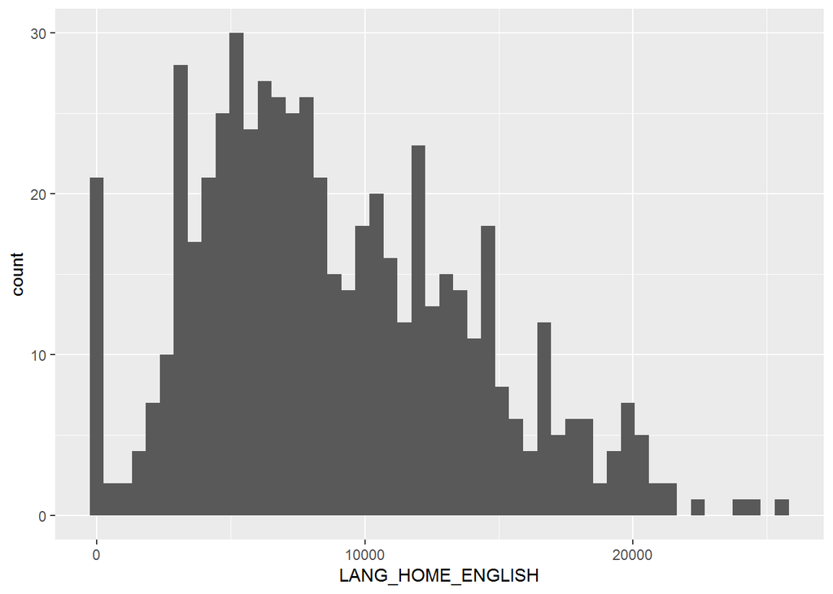

```r
# Plot the number of homes where english is the langauage spoken at home
nsw_lah_data %>%
  ggplot() +
  geom_histogram(aes(x = LANG_HOME_ENGLISH), bins = 50)
```

The data for when English is the language spoken at home seems normally distributed. What does the QQ plot say?

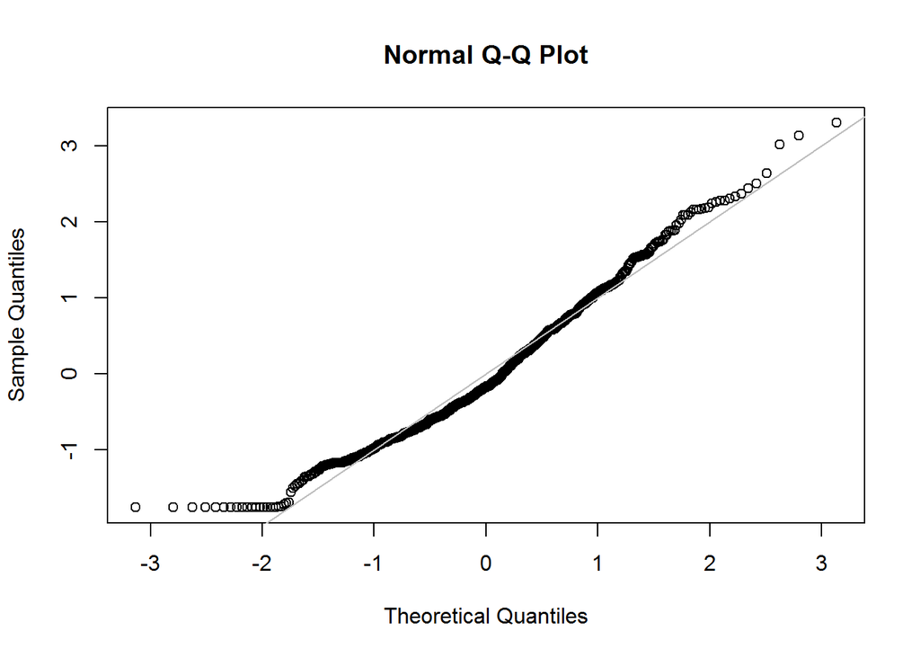

```r
# Other than the tail (the zeros) it seems to be close to normal distribution
lah_std <- scale(nsw_lah_data$LANG_HOME_ENGLISH)
qqnorm(lah_std)
abline(a = 0, b = 1, col = 'grey')
```

Other than the zeros the data is fairly well normally distributed.

Some SA2’s appear to have zero homes where English is spoken at home. Where are these places?

```r
# Some SA2's have zero homes that speak English - where are they?
nsw_lah_data %>%
  filter(LANG_HOME_ENGLISH < 10) %>%
  select(SA2_CODE, SA2_NAME_2016, LANG_HOME_ENGLISH)
```

```
## # A tibble: 11 x 3
##     SA2_CODE SA2_NAME_2016               LANG_HOME_ENGLISH
##        <int> <chr>                                   <int>
##  1 103031075 Wollangambe - Wollemi                       0
##  2 107011133 Port Kembla Industrial                      6
##  3 107021135 Illawarra Catchment Reserve                 7
##  4 117011324 Port Botany Industrial                      3
##  5 118011342 Centennial Park                             0
##  6 123021439 Holsworthy Military Area                    0
##  7 124021456 Blue Mountains - South                      3
##  8 125011475 Rookwood Cemetery                           3
##  9 125031486 Smithfield Industrial                       3
## 10 125031487 Yennora Industrial                          3
## 11 127021521 Wetherill Park Industrial                   9
```

These are industrial areas, military bases and a cemetery (three dwellings speak English at home in Rockwood Cemetery - spooky).

These are the total number of households where English is spoken. What about the percentages? Do they differ much?

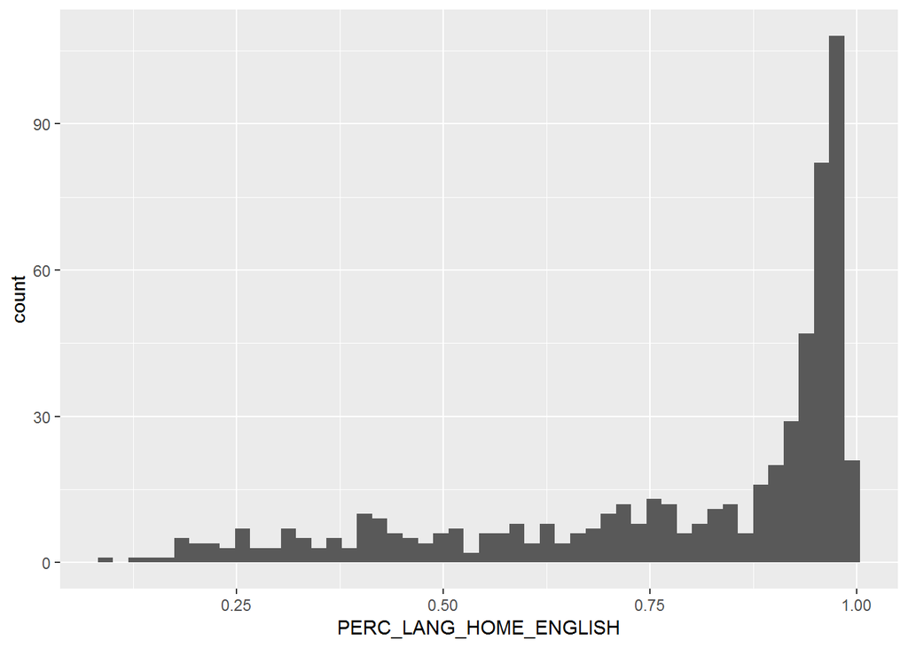

```r
# What about percentages
nsw_lah_data %>%
  ggplot() +
  geom_histogram(aes(x = PERC_LANG_HOME_ENGLISH), bins = 50)
```

And the QQ plot

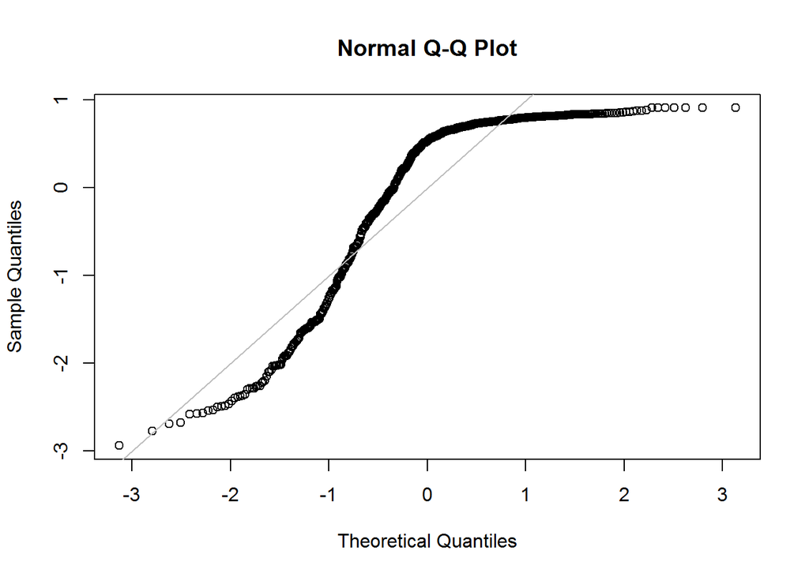

```r
lah_std <- scale(nsw_lah_data$PERC_LANG_HOME_ENGLISH)
qqnorm(lah_std)
abline(a = 0, b = 1, col = 'grey')
```

```r
nsw_lah_data %>%
  filter(PERC_LANG_HOME_ENGLISH < 0.25) %>%
  select(SA2_CODE, SA2_NAME_2016, PERC_LANG_HOME_ENGLISH) %>%
  arrange(PERC_LANG_HOME_ENGLISH)
```

```
## # A tibble: 20 x 3
##     SA2_CODE SA2_NAME_2016                PERC_LANG_HOME_ENGLISH
##        <int> <chr>                                         <dbl>
##  1 125011583 Auburn - North                               0.0976
##  2 125011582 Auburn - Central                             0.137
##  3 127021511 Cabramatta - Lansvale                        0.155
##  4 119021573 Lakemba                                      0.159
##  5 127021515 Fairfield                                    0.182
##  6 119011572 Bankstown - South                            0.183
##  7 119021574 Wiley Park                                   0.185
##  8 127021513 Canley Vale - Canley Heights                 0.192
##  9 125011584 Auburn - South                               0.193
## 10 125011586 Lidcombe                                     0.200
## 11 119011571 Bankstown - North                            0.202
## 12 119031368 Hurstville                                   0.204
## 13 125041492 Parramatta - Rosehill                        0.209
## 14 125011585 Berala                                       0.218
## 15 127021520 St Johns Park - Wakeley                      0.225
## 16 119011355 Chullora                                     0.228
## 17 119021363 Canterbury (South) - Campsie                 0.230
## 18 120031396 Homebush                                     0.231
## 19 119021366 Punchbowl                                    0.234
## 20 127021516 Fairfield - West                             0.248
```

Only 10% of people speak English in Auburn North; 14% in Auburn Central. Wow that surprises me a little.

Before we go any further let’s do a check for NA values.

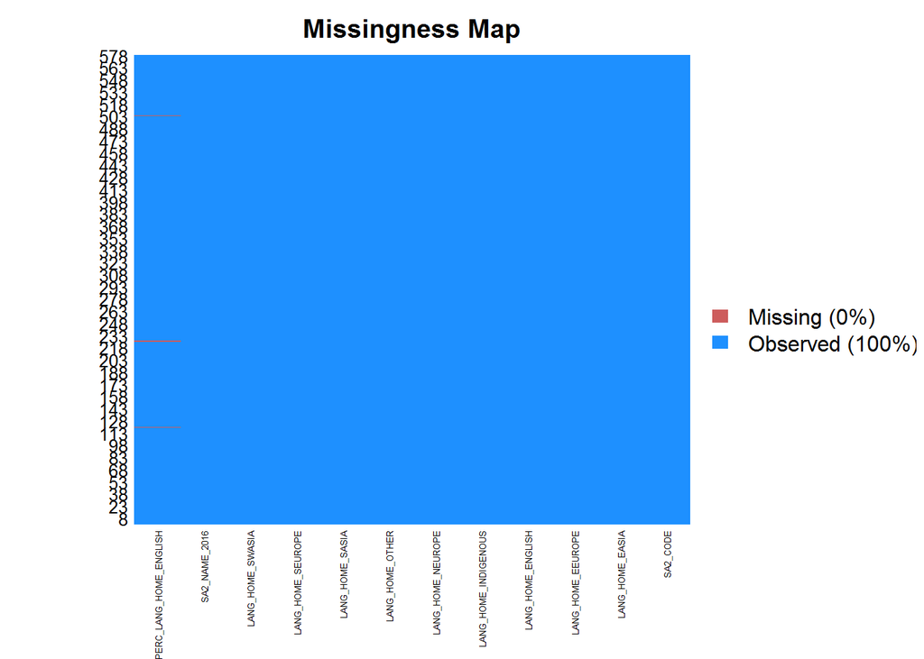

```r
missmap(nsw_lah_data, x.cex = 0.4)
```

There isn’t a lot of missing data. A couple of missing PERC_LANG_HOME_ENGLISH values but otherwise it is pretty complete. Where are these missing values? And why?

```r
nsw_lah_data %>%
  filter(is.na(PERC_LANG_HOME_ENGLISH)) %>%
  select(SA2_CODE, SA2_NAME_2016, PERC_LANG_HOME_ENGLISH, LANG_HOME_ENGLISH)
```

```
## # A tibble: 3 x 4
##    SA2_CODE SA2_NAME_2016           PERC_LANG_HOME_ENGLISH LANG_HOME_ENGLI~
##       <int> <chr>                                    <dbl>            <int>
## 1 103031075 Wollangambe - Wollemi                      NaN                0
## 2 118011342 Centennial Park                            NaN                0
## 3 123021439 Holsworthy Military Ar~                    NaN                0
```

The usual suspects. Caused by zero values for each of the inputs into the percentage calculation. I could set these to zero percent, or just remove from the dataset …. hmmm decisions.

Whilst I’m making that decision lets see how language at home looks against unemployment rates.

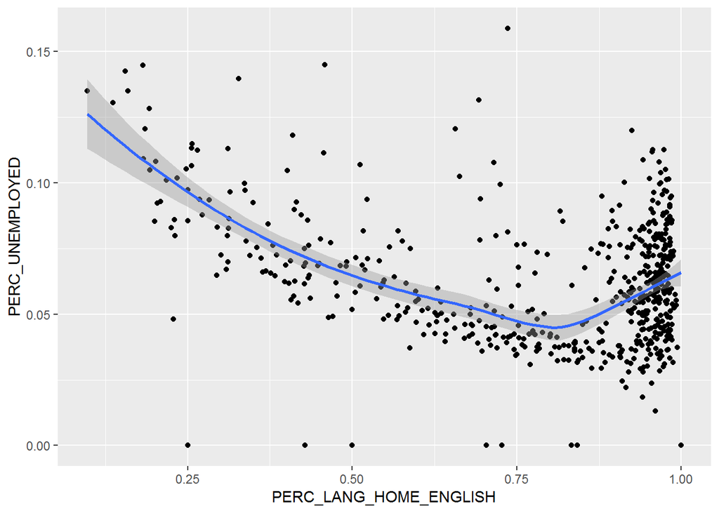

```r
nsw_lah_data %>%
  inner_join(employed_data, by = c("SA2_CODE")) %>%
  filter(PERC_UNEMPLOYED < 0.2) %>%
  ggplot() +
  geom_point(aes(x = PERC_LANG_HOME_ENGLISH, y = PERC_UNEMPLOYED)) +
  geom_smooth(aes(x = PERC_LANG_HOME_ENGLISH, y = PERC_UNEMPLOYED))
```

There seems to be a slight relationship. The SA2’s with the lowest % of people speaking English at home have the highest unemployment rates.

Why not check if there is a relationship for a particular language.

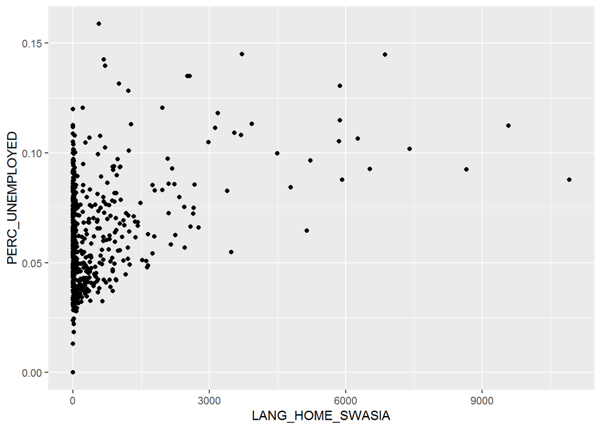

```r
nsw_lah_data %>%
  inner_join(employed_data, by = c("SA2_CODE")) %>%
  filter(PERC_UNEMPLOYED < 0.2) %>%
  ggplot() +
  geom_point(aes(x = LANG_HOME_SWASIA, y = PERC_UNEMPLOYED))
```

Plots for other languages looked similar to South West Asia represented here. Maybe we need to go to a finer level of granularity.

Now we’ll do some stuff with maps because that is cool.

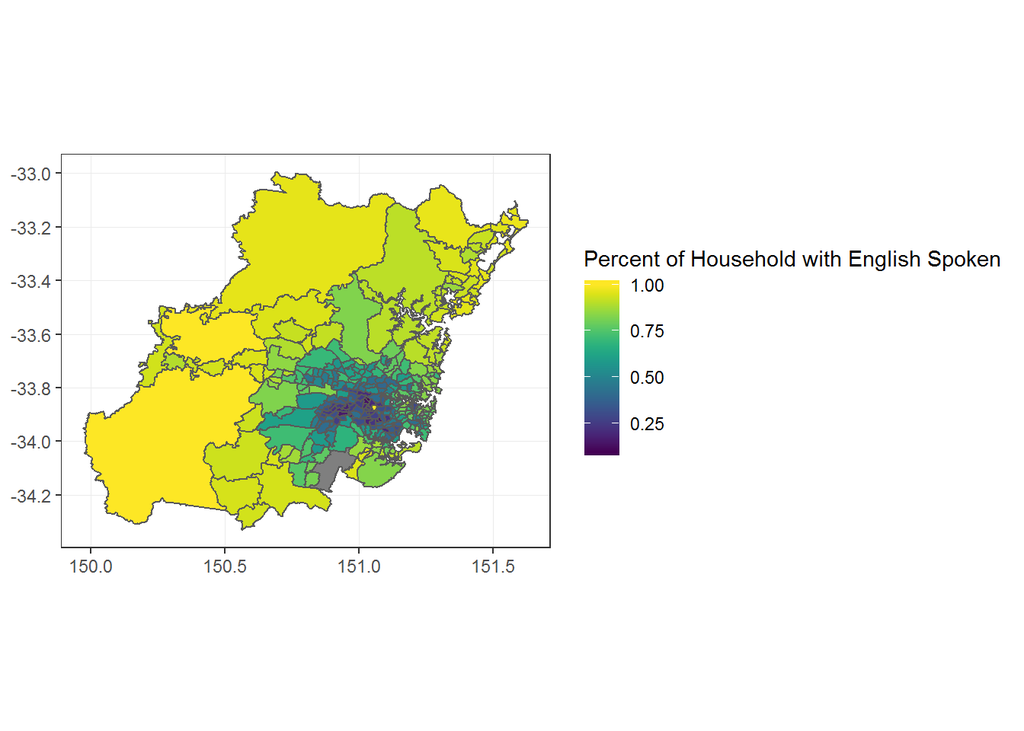

```r
# Now we'll do some stuff with maps - because they look cool
sa2_shape <- st_read("../../Raw Data/Data Files/ABS/SA2_Shapefile/SA2_2016_AUST.shp", quiet = TRUE)
combined_df <- merge(nsw_lah_data, sa2_shape, by.x = "SA2_CODE", by.y = "SA2_MAIN16")

# For greater Sydney to start with
combined_df %>%
  filter(GCC_NAME16 == "Greater Sydney") %>%
  ggplot() +
  geom_sf(aes(fill = PERC_LANG_HOME_ENGLISH)) +
  scale_fill_viridis("Percent of Household with English Spoken") +
  theme_bw()
```

West and south west Sydney have a lower percentage of households where English is spoken at home. If you look at the unemployment rate these are the same areas with higher levels of unemployment.

What about the rest of NSW

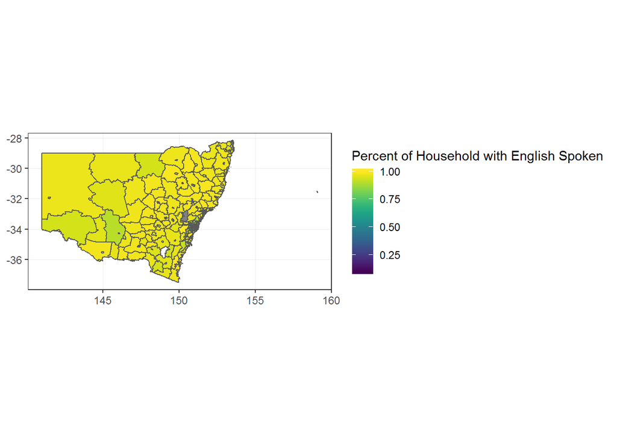

```r
combined_df %>%
  ggplot() +
  geom_sf(aes(fill = PERC_LANG_HOME_ENGLISH)) +
  scale_fill_viridis("Percent of Household with English Spoken") +
  theme_bw()
```

And the state is pretty much yellow, i.e. low numbers of people speaking anything other than English at home. Migrants tend to congregate in major city centres and this map seems to confirm that.

Lets run a correlation test to see if any of the variables relate to each other.

```r
# Check correlation between variables
nsw_lah_matrix <- nsw_lah_data %>%
  select(LANG_HOME_ENGLISH,LANG_HOME_EASIA,LANG_HOME_NEUROPE,LANG_HOME_INDIGENOUS,LANG_HOME_EEUROPE,LANG_HOME_OTHER,LANG_HOME_SASIA,LANG_HOME_SEUROPE,
         LANG_HOME_SWASIA) %>%
  as.matrix()

# Show values - nothing really high
rcorr(nsw_lah_matrix, type = "pearson")
```

```
##                      LANG_HOME_ENGLISH LANG_HOME_EASIA LANG_HOME_NEUROPE
## LANG_HOME_ENGLISH                 1.00            0.03              0.60
## LANG_HOME_EASIA                   0.03            1.00              0.19
## LANG_HOME_NEUROPE                 0.60            0.19              1.00
## LANG_HOME_INDIGENOUS              0.23           -0.14             -0.06
## LANG_HOME_EEUROPE                 0.14            0.36              0.25
## LANG_HOME_OTHER                  -0.06            0.34             -0.02
## LANG_HOME_SASIA                   0.00            0.39             -0.01
## LANG_HOME_SEUROPE                 0.19            0.40              0.33
## LANG_HOME_SWASIA                 -0.11            0.24             -0.08
##                      LANG_HOME_INDIGENOUS LANG_HOME_EEUROPE
## LANG_HOME_ENGLISH                    0.23              0.14
## LANG_HOME_EASIA                     -0.14              0.36
## LANG_HOME_NEUROPE                   -0.06              0.25
## LANG_HOME_INDIGENOUS                 1.00             -0.15
## LANG_HOME_EEUROPE                   -0.15              1.00
## LANG_HOME_OTHER                     -0.09              0.48
## LANG_HOME_SASIA                     -0.11              0.32
## LANG_HOME_SEUROPE                   -0.12              0.63
## LANG_HOME_SWASIA                    -0.12              0.47
##                      LANG_HOME_OTHER LANG_HOME_SASIA LANG_HOME_SEUROPE
## LANG_HOME_ENGLISH              -0.06            0.00              0.19
## LANG_HOME_EASIA                 0.34            0.39              0.40
## LANG_HOME_NEUROPE              -0.02           -0.01              0.33
## LANG_HOME_INDIGENOUS           -0.09           -0.11             -0.12
## LANG_HOME_EEUROPE               0.48            0.32              0.63
## LANG_HOME_OTHER                 1.00            0.36              0.36
## LANG_HOME_SASIA                 0.36            1.00              0.25
## LANG_HOME_SEUROPE               0.36            0.25              1.00
## LANG_HOME_SWASIA                0.51            0.38              0.40
##                      LANG_HOME_SWASIA
## LANG_HOME_ENGLISH               -0.11
## LANG_HOME_EASIA                  0.24
## LANG_HOME_NEUROPE               -0.08
## LANG_HOME_INDIGENOUS            -0.12
## LANG_HOME_EEUROPE                0.47
## LANG_HOME_OTHER                  0.51
## LANG_HOME_SASIA                  0.38
## LANG_HOME_SEUROPE                0.40
## LANG_HOME_SWASIA                 1.00
```

[output cut: 30 more lines]

```
## LANG_HOME_EEUROPE    0.0000          0.0000          0.0000
## LANG_HOME_OTHER                      0.0000          0.0000
## LANG_HOME_SASIA      0.0000                          0.0000
## LANG_HOME_SEUROPE    0.0000          0.0000
## LANG_HOME_SWASIA     0.0000          0.0000          0.0000
##                      LANG_HOME_SWASIA
## LANG_HOME_ENGLISH    0.0076
## LANG_HOME_EASIA      0.0000
## LANG_HOME_NEUROPE    0.0615
## LANG_HOME_INDIGENOUS 0.0035
## LANG_HOME_EEUROPE    0.0000
## LANG_HOME_OTHER      0.0000
## LANG_HOME_SASIA      0.0000
## LANG_HOME_SEUROPE    0.0000
## LANG_HOME_SWASIA
```

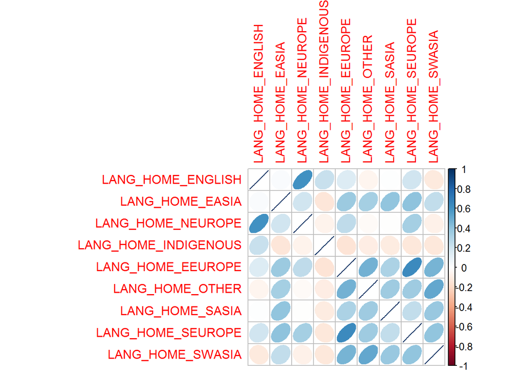

```r
# And a plot for good measure
corrplot(cor(nsw_lah_matrix), method = "ellipse")
```

Interestingly there seems to be a relationship between people that speak a Northern European language (e.g. Frensh, Swedish) and areas where English is widely spoken. A similar relationship appears between Southern and Eastern Europeans.

I find the slightly negative correlation between indgenous languages and non-English languages interesting. Do new migrants not settle in areas where more traditional aboriginals live? Probably not as I imagine aboriginal languages exist outside of major city centres. Does this impact a migrants understanding of aboriginal life and culture? What impact does this have on aboriginal policies etc.

#### Conclusion

Language at home does seem to have a relationship with unemployment rate and may help the model determine unemployment rates.